# OAS1 - structure plots, heat maps and further exploration

We first look at the structure plot

```r
library(gplots)
library(smash)
path = "D:/Grad School/projects/sequence_clustering"
setwd(path)
load("results/analysis_oas1/res_nosmooth_3.RData")
res_nosmooth = res
load("results/analysis_oas1/res_smooth_3.RData")
res_smooth = res
load(paste0(path, "/data/oas1/OAS1.Robj"))
```

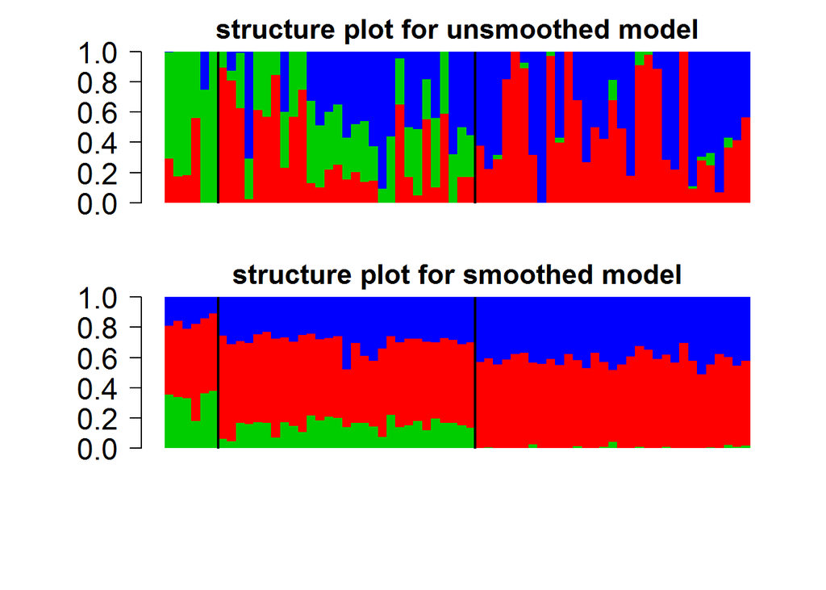

```r
K = dim(res_nosmooth$pi)[2]
nosmooth_pi_unordered = res_nosmooth$pi
ordering = order(Robj$g)
nosmooth_pi_ordered = nosmooth_pi_unordered[ordering, ]
smooth_pi_unordered = res_smooth$pi
smooth_pi_ordered = smooth_pi_unordered[ordering, ]
sep_lines = cumsum(table(Robj$g))[1:(K - 1)]

par(mfrow = c(2, 1), mar=c(2, 2, 2, 2), oma = c(4, 4, 0.2, 0.2))
barplot(t(nosmooth_pi_ordered), col = 2:(K + 1), axisnames = F, space = 0, border = NA, main = "structure plot for unsmoothed model", las = 1, ylim = c(0, 1), cex.axis = 1.5, cex.main = 1.4)
abline(v = sep_lines, lwd = 2)
barplot(t(smooth_pi_ordered), col = c(3, 2, 4:(K + 1)), axisnames = F, space = 0, border = NA, main = "structure plot for smoothed model", las = 1, ylim = c(0, 1), cex.axis = 1.5, cex.main = 1.4)
abline(v = sep_lines, lwd = 2)
```

Now we take a look at the heatmap for genotypes 1 and 2. First heatmap shows correlation for raw reads, second shows correlation for admixture proportions using the model with no smoothing, and the third shows correlation for admixture proportions using the model with smoothing.

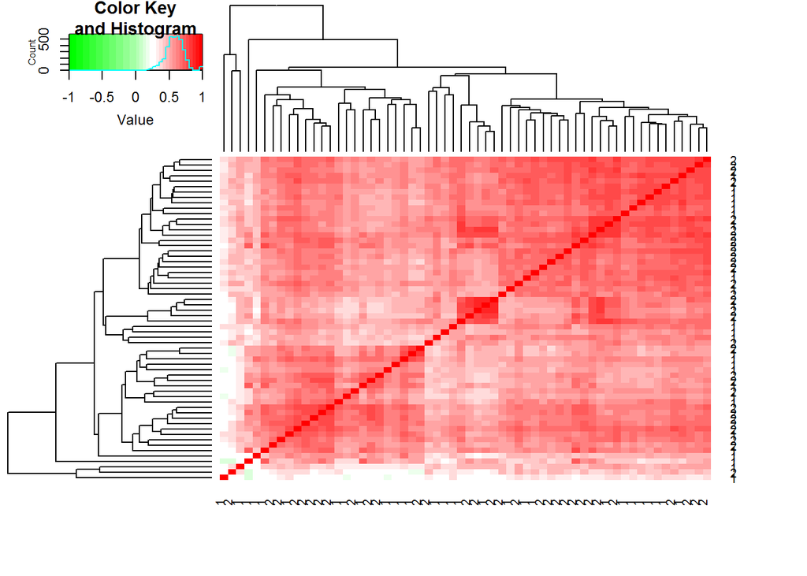

```r
data_subset = data[Robj$g!=0, 2049:4096]
g_subset = Robj$g[Robj$g != 0]

col = c(rgb(seq(0, 1, length = 15), 1, seq(0, 1, length = 15)), rgb(1, seq(1, 0 ,length = 15), seq(1, 0, length = 15)))

heatmap.2(cor(t(data_subset), method = "pearson"), labCol = g_subset, labRow = g_subset, scale = "none", trace = "none", distfun = function(x) dist(x, method = "euclidean"), col = col, hclustfun = function(x) hclust(x,method="average"), breaks = c(seq(-1, 0, 0.1), seq(0.05, 1, length.out = 20)))
```

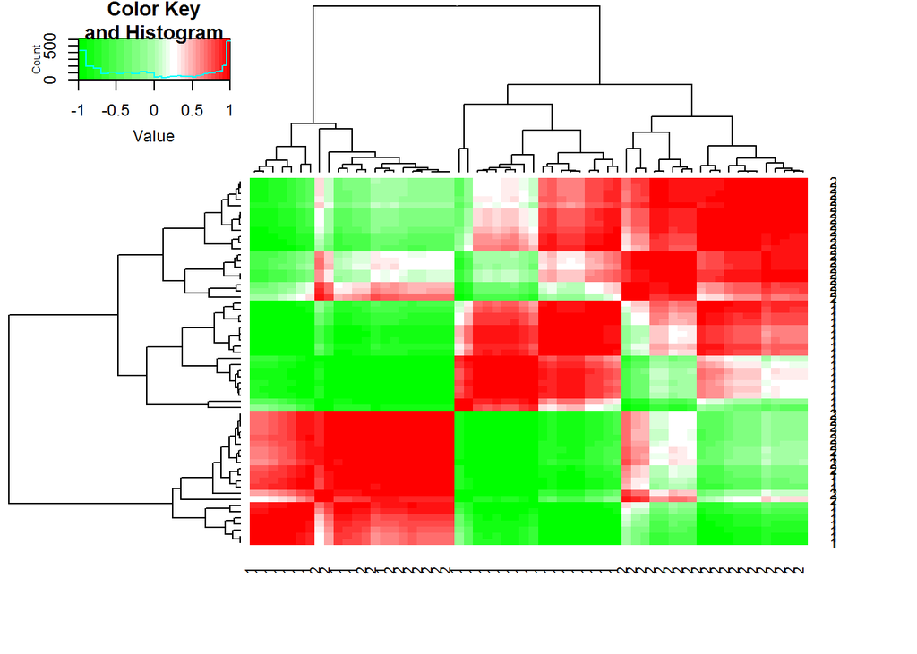

```r
nosmooth_subset = res_nosmooth$pi[Robj$g!=0, ]

hm_nosmooth_12 = heatmap.2(cor(t(nosmooth_subset), method = "pearson"), labCol = g_subset, labRow = g_subset, scale = "none", trace = "none", distfun = function(x) dist(x, method = "euclidean"), col = col, hclustfun = function(x) hclust(x,method="average"), breaks = c(seq(-1, 0, 0.1), seq(0.05, 1, length.out = 20)))
```

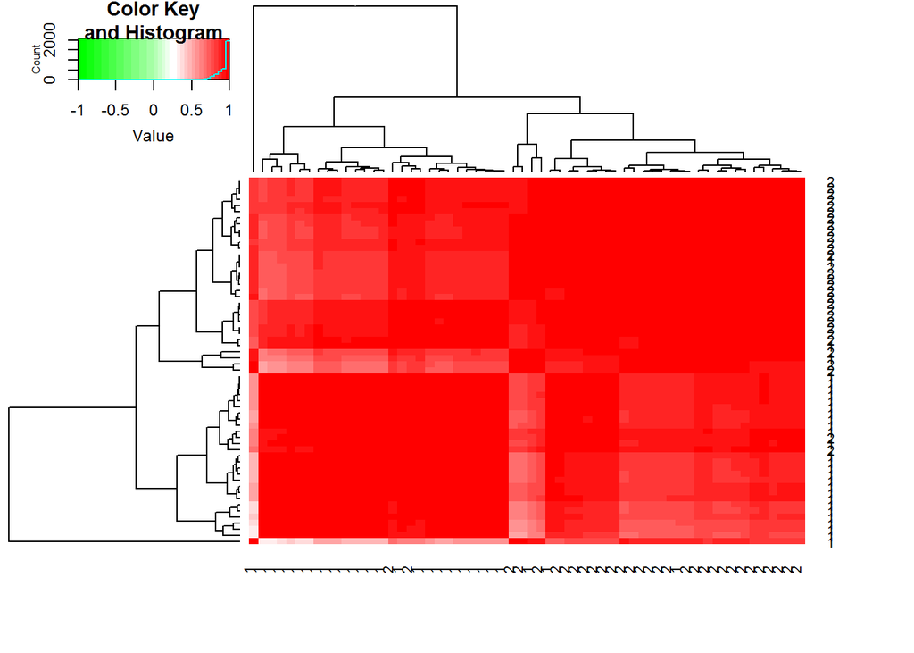

```r
smooth_subset = res_smooth$pi[Robj$g!=0, ]

heatmap.2(cor(t(smooth_subset), method = "pearson"), labCol = g_subset, labRow = g_subset, scale = "none", trace = "none", distfun = function(x) dist(x, method = "euclidean"), col = col, hclustfun = function(x) hclust(x,method="average"), breaks = c(seq(-1, 0, 0.1), seq(0.05, 1, length.out = 20)))
```

As we can see there isn’t a lot of structure using raw reads. However, the unsmoothed model shows some strong anticorrelation between certain samples, which is weird considering the similarities between samples in genotype classes 1 and 2. On the other hand, the model with smoothing shows that while all the samples in either genotype class are perfectly correlated with those in the sample genotype class, samples between genotype classes are also very similar.

Now we draw the same heatmaps, but for genotypes 0 and 2.

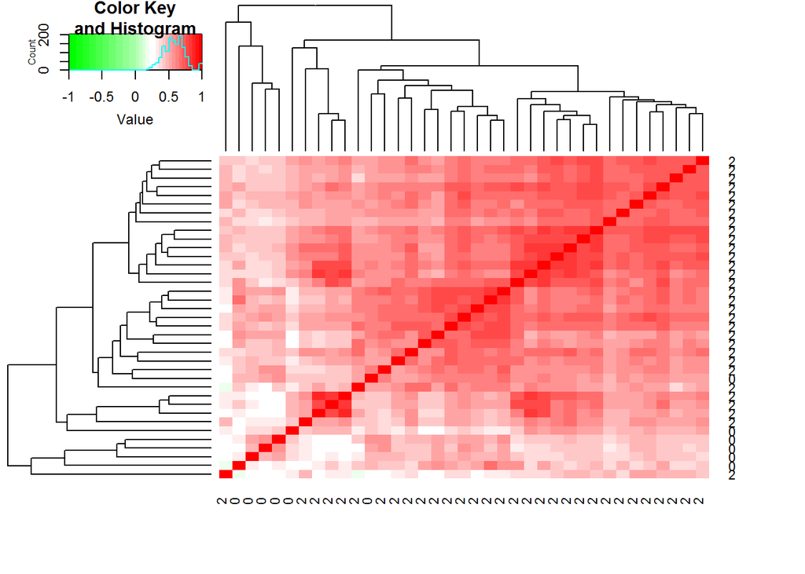

```r
data_subset = data[Robj$g!=1, 2049:4096]
g_subset = Robj$g[Robj$g != 1]

col = c(rgb(seq(0, 1, length = 15), 1, seq(0, 1, length = 15)), rgb(1, seq(1, 0 ,length = 15), seq(1, 0, length = 15)))

heatmap.2(cor(t(data_subset), method = "pearson"), labCol = g_subset, labRow = g_subset, scale = "none", trace = "none", distfun = function(x) dist(x, method = "euclidean"), col = col, hclustfun = function(x) hclust(x,method="average"), breaks = c(seq(-1, 0, 0.1), seq(0.05, 1, length.out = 20)))
```

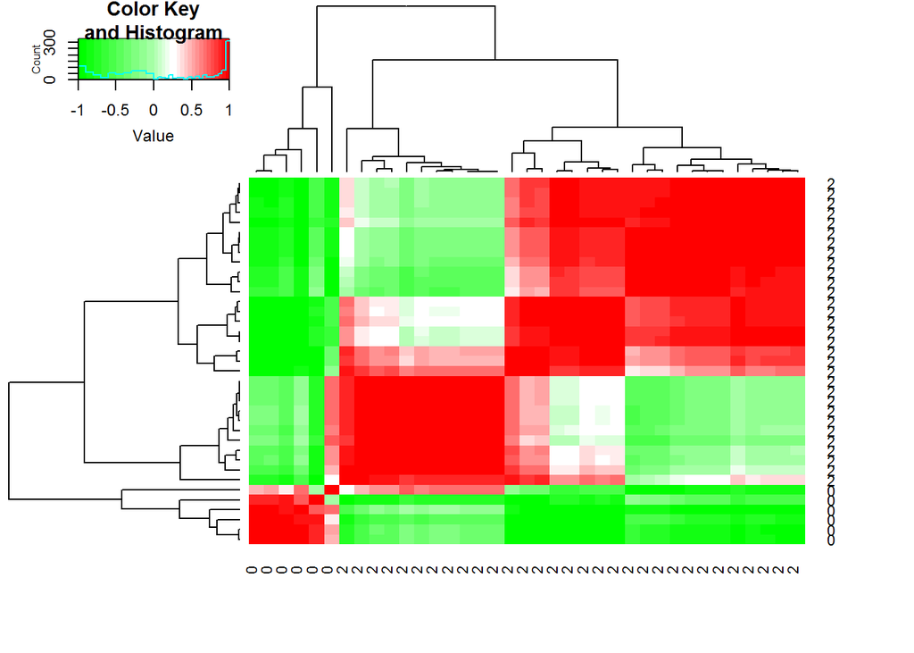

```r
nosmooth_subset = res_nosmooth$pi[Robj$g!=1, ]

hm_nosmooth_02 = heatmap.2(cor(t(nosmooth_subset), method = "pearson"), labCol = g_subset, labRow = g_subset, scale = "none", trace = "none", distfun = function(x) dist(x, method = "euclidean"), col = col, hclustfun = function(x) hclust(x,method="average"), breaks = c(seq(-1, 0, 0.1), seq(0.05, 1, length.out = 20)))
```

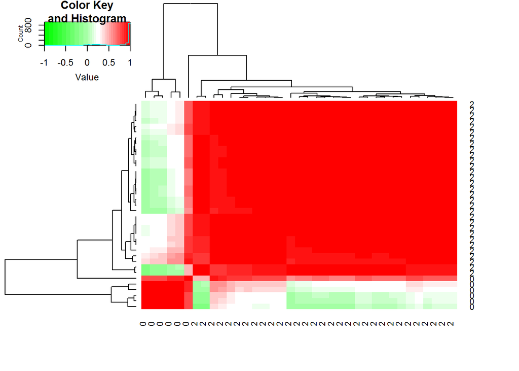

```r
smooth_subset = res_smooth$pi[Robj$g!=1, ]

hm_smooth_02 = heatmap.2(cor(t(smooth_subset), method = "pearson"), labCol = g_subset, labRow = g_subset, scale = "none", trace = "none", distfun = function(x) dist(x, method = "euclidean"), col = col, hclustfun = function(x) hclust(x,method="average"), breaks = c(seq(-1, 0, 0.1), seq(0.05, 1, length.out = 20)))
```

Finally, for genotypes 0 and 1

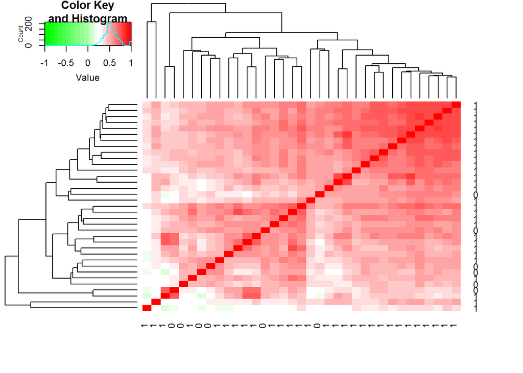

```r
data_subset = data[Robj$g!=2, 2049:4096]
g_subset = Robj$g[Robj$g != 2]

col = c(rgb(seq(0, 1, length = 15), 1, seq(0, 1, length = 15)), rgb(1, seq(1, 0 ,length = 15), seq(1, 0, length = 15)))

heatmap.2(cor(t(data_subset), method = "pearson"), labCol = g_subset, labRow = g_subset, scale = "none", trace = "none", distfun = function(x) dist(x, method = "euclidean"), col = col, hclustfun = function(x) hclust(x,method="average"), breaks = c(seq(-1, 0, 0.1), seq(0.05, 1, length.out = 20)))
```

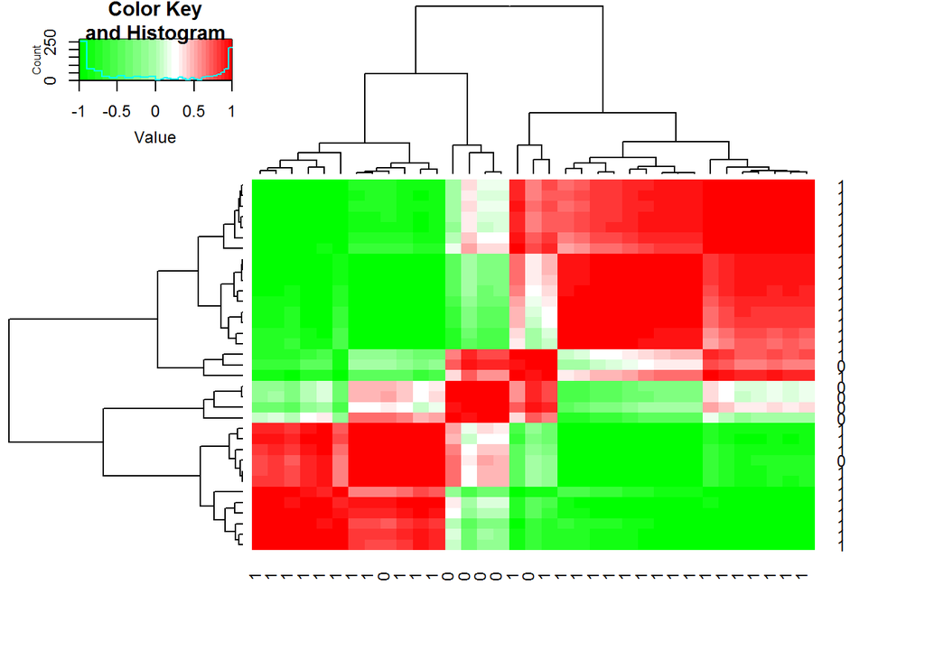

```r
nosmooth_subset = res_nosmooth$pi[Robj$g!=2, ]

hm_nosmooth_01 = heatmap.2(cor(t(nosmooth_subset), method = "pearson"), labCol = g_subset, labRow = g_subset, scale = "none", trace = "none", distfun = function(x) dist(x, method = "euclidean"), col = col, hclustfun = function(x) hclust(x,method="average"), breaks = c(seq(-1, 0, 0.1), seq(0.05, 1, length.out = 20)))
```

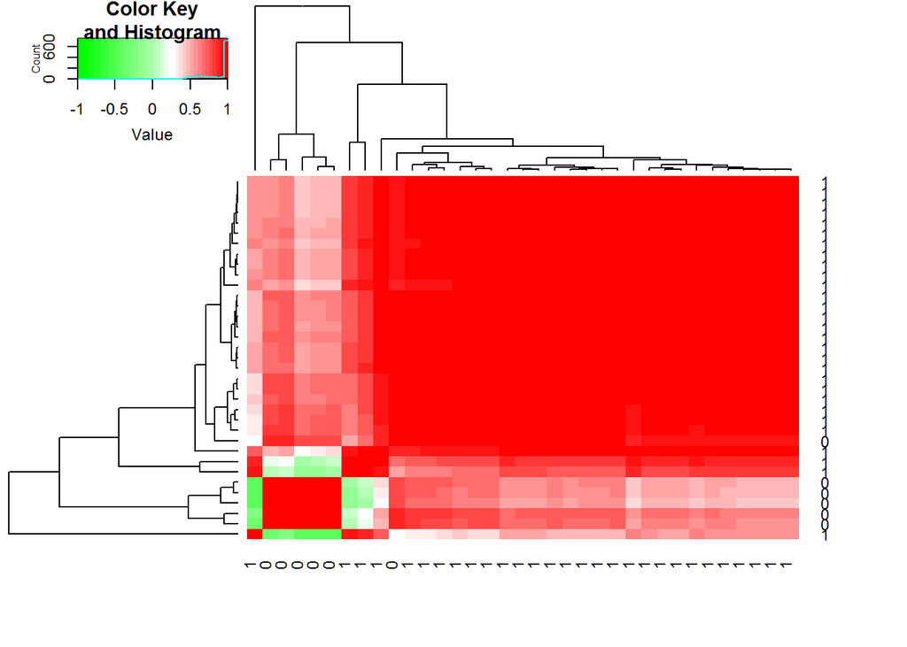

```r
smooth_subset = res_smooth$pi[Robj$g!=2, ]

hm_smooth_01 = heatmap.2(cor(t(smooth_subset), method = "pearson"), labCol = g_subset, labRow = g_subset, scale = "none", trace = "none", distfun = function(x) dist(x, method = "euclidean"), col = col, hclustfun = function(x) hclust(x,method="average"), breaks = c(seq(-1, 0, 0.1), seq(0.05, 1, length.out = 20)))
```

Again the heatmap for the raw data doesn’t reveal much structure; the heatmap for the model without smoothing makes little sense, and the heatmap for the model with smoothing reveals the expected patterns. One sample from genotype class 0 is of particular interest; we will discuss more below.

We look at two examples where two samples from genotype class 1 have very different correlations in the smoothed vs the unsmoothed model.

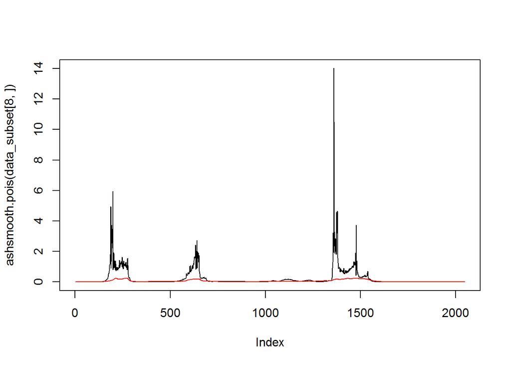

```r
data_subset = data[Robj$g!=2, 2049:4096]
g_subset = Robj$g[Robj$g != 2]
nosmooth_subset = res_nosmooth$pi[Robj$g!=2, ]
smooth_subset = res_smooth$pi[Robj$g!=2, ]

#8 & 21
par(mfrow = c(1, 1))
plot(ashsmooth.pois(data_subset[8, ]), type = 'l')
lines(ashsmooth.pois(data_subset[21, ]), col = 2)
```

```r
cor(t(data_subset), method = "pearson")[8, 21]
```

```
## [1] 0.2349948
```

```r
cor(t(nosmooth_subset), method = "pearson")[8, 21]
```

```
## [1] -0.9998393
```

```r
cor(t(smooth_subset), method = "pearson")[8, 21]
```

```
## [1] 0.8762195
```

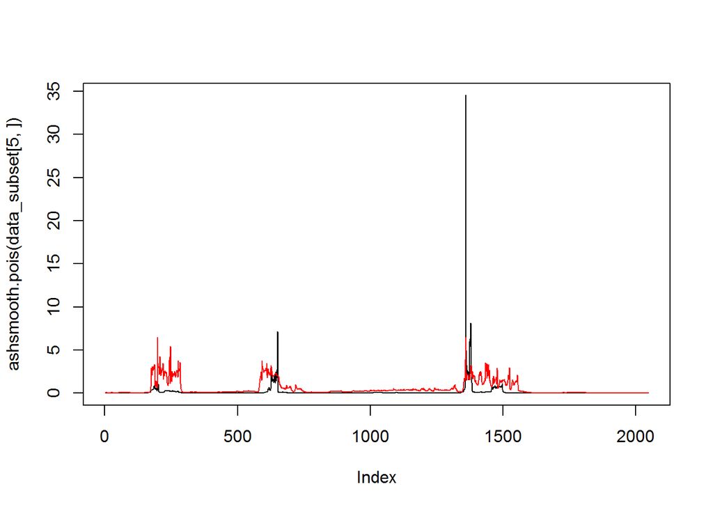

```r
data_subset = data[Robj$g!=0, 2049:4096]
g_subset = Robj$g[Robj$g != 0]
nosmooth_subset = res_nosmooth$pi[Robj$g!=0, ]
smooth_subset = res_smooth$pi[Robj$g!=0, ]

#5 & 26, both from genotype 1
par(mfrow = c(1, 1))
plot(ashsmooth.pois(data_subset[5, ]), type = 'l')
lines(ashsmooth.pois(data_subset[26, ]), col = 2)
```

```r
cor(t(data_subset), method = "pearson")[5, 26]
```

```
## [1] 0.414831
```

```r
cor(t(nosmooth_subset), method = "pearson")[5, 26]
```

```
## [1] -0.9878675
```

```r
cor(t(smooth_subset), method = "pearson")[5, 26]
```

```
## [1] 0.964406
```

And now the same for genotype class 2

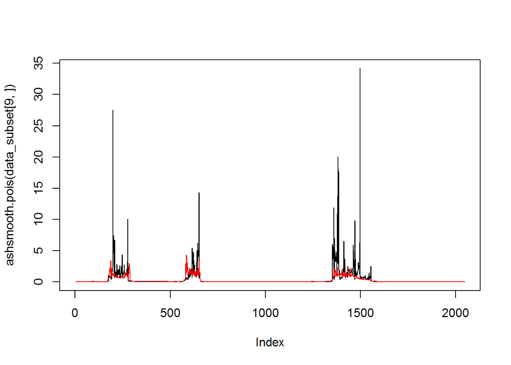

```r
data_subset = data[Robj$g!=1, 2049:4096]
g_subset = Robj$g[Robj$g != 1]
nosmooth_subset = res_nosmooth$pi[Robj$g!=1, ]
smooth_subset = res_smooth$pi[Robj$g!=1, ]

#9 & 23
par(mfrow = c(1, 1))
plot(ashsmooth.pois(data_subset[9, ]), type = 'l')
lines(ashsmooth.pois(data_subset[23, ]), col = 2)
```

```r
cor(t(data_subset), method = "pearson")[9, 23]
```

```
## [1] 0.427477
```

```r
cor(t(nosmooth_subset), method = "pearson")[9, 23]
```

```
## [1] -0.5737838
```

```r
cor(t(smooth_subset), method = "pearson")[9, 23]
```

```
## [1] 0.9368441
```

Finally we look at the one sample from genotype class 0 that seems different from the others

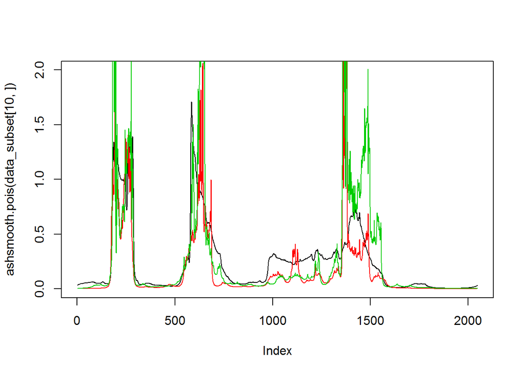

```r
data_subset = data[Robj$g!=2, 2049:4096]
g_subset = Robj$g[Robj$g != 2]
nosmooth_subset = res_nosmooth$pi[Robj$g!=2, ]
smooth_subset = res_smooth$pi[Robj$g!=2, ]

#10 (0) & 20 (0) & 30 (1); 20 (red) seems similar to both 10 (black) and 30 (green)
par(mfrow = c(1, 1))
plot(ashsmooth.pois(data_subset[10, ]), ylim = c(0, 2), type = 'l')
lines(ashsmooth.pois(data_subset[20, ]), col = 2)
lines(ashsmooth.pois(data_subset[30, ]), col = 3)
```

```r
cor(t(data_subset), method = "pearson")[10, 20]
```

```
## [1] 0.2896969
```

```r
cor(t(nosmooth_subset), method = "pearson")[10, 20]
```

```
## [1] 0.4988818
```

```r
cor(t(smooth_subset), method = "pearson")[10, 20]
```

```
## [1] 0.8584378
```

```r
cor(t(data_subset), method = "pearson")[30, 20]
```

```
## [1] 0.6532714
```

```r
cor(t(nosmooth_subset), method = "pearson")[30, 20]
```

```
## [1] 0.8097609
```

```r
cor(t(smooth_subset), method = "pearson")[30, 20]
```

```
## [1] 0.9245916
```